# Ch. 49: Flows on the line

Instructor notes for Chapter 49

Daniel Kaplan  
2022-03-13

## Student outcomes:

- V-YGS71: Find the location of fixed points in a one-state-variable system by finding zeros of the dynamical function:
  - graphically or computationally when all parameters are known
  - analytically in simple cases (e.g. quadratic polynomial)
- J-YOLEG: Deduce the stability of a fixed point by:
  - examination of the slope of the dynamical function in a first-order system
- F-QSK86: Identify the long-term behavior of trajectories starting near an unstable fixed point. For first-order systems, identify when the long-term behavior terminates at a stable fixed point, and which one.
- X-DE4WK: Construct the linear approximation to a dynamical function at a fixed point:
  - evaluate the derivative of the dynamical functions at the fixed point
  - for systems, construct the matrix representation of the linear dynamics centered at the fixed point.
- C-QDOXL: Given a first-order differential equation of the form $\partial_t x = a x + b$, find the solution analytically in terms of $x$.
  - Determine the location of the fixed point $x^\star$.
  - Translate the equation to be in terms of $y$, where $y = x - x^\star$.
  - Write down the solution in terms of $y$.
  - Translate the solution back to be in term of $x$.
- L-ZPTTA: Verify (by differentiation) a proposed solution to a first-order differential equation.
- L-ZPDIJ: Construct graphs, with properly labeled axes, of
  - Newton’s Law of Cooling
  - population growth with and without a carrying capacity

Still relevant …

- N-O88YI: From a trajectory drawn on a graph of a flow field, construct a plausible time-series plot

## Overview

This chapter is about continuous-time systems with one state variable. There are four main objectives of this chapter:

1. Re-inforce the connection between a *dynamical function* and the flow field.
2. Establish an awareness of fixed points in dynamics, showing what they look like in a flow field as well as the flow.
3. (Re-)introduce the concept of a linear approximation to a function and justify the exponential form of the “solutions,” at least close to the fixed point. This exponential form, $e^{at}$, will also be important when we work with systems with multiple state variables. Taylor polynomial, no constant point.
4. Introduce basic function forms in differential equations and the idea of breaking down the overall change into components.

(1)-(4) are important foundations for the rest of Block 6. As usual in *MOSAIC Calculus* there is both a graphical and an algebraic presentation of each of these functions.

Another valuable potential use for the chapter relates to student motivation. Students are often strongly motivated by applications to the real world, and the one presented in the last section of this chapter has a powerful lesson to teach about agricultural sustainability. It was originally presented in a 1977 **Nature** review paper by Robert May. (This paper is also a valuable source of examples of the phenomena that can be created by simple flows on the phase plane.) I encourage instructors to devote class time by working carefully through the model, starting first with low numbers of cows where the behavior is simple, and pointing out that there is a qualitative change in the dynamics as more cows are added, but leaving the students collectively to sort out what that qualitative change is and its consequences.

## Flows with a single state variable

There are many straightforward settings where a system can be well modeled with only a single state variable. Famous ones are

- Newton’s law of cooling, where the temperature $T$ of an object surrounded by an ambient environment at temperature $T_A$ is modeled by $\partial_t T = -k (T - T_A)$. The state variable is $T$. The ambient temperature $T_A$ is presumed to be constant because the environment is much larger than the cooling object. (Larger = “more heat capacity”.)
- Radioactive decay, where the state variable is the amount of mass $M$ of the radioactive material. $\partial_t M = -k M$
- Credit card debt, where the state variable is the amount of debt $D$. $\partial_t M = r M$, where the dimension of the parameter $r$ is T<sup>-1</sup>, as in “2.5 percent per month.”

A useful tool for displaying dynamics on the phase line is a combination plot where the state space is the $x$ axis. The input to the dynamical function is that same $x$ axis, with the output being plotted as the vertical coordinate. (This function is part of the `{Znotes}` package, which contains among other things software for making specialized pedagogical graphics. To install `{Znotes}`, use the R command `remotes::install_github("dtkaplan/Znotes")`) The flow vectors are horizontal because they must always be vectors in the state space, which is presented here as a horizontal line.

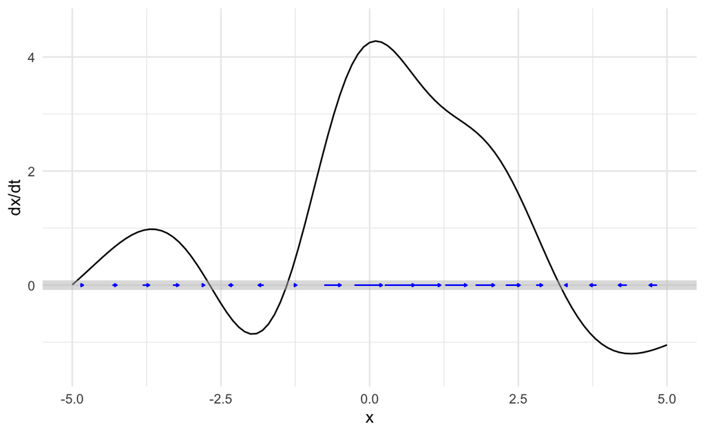

```r
dyn_function <- rfun( ~ x, seed=101)
Znotes::phase_line(dyn_function(x) ~ x, domain(x=-5:5), narrows=20)
```

Here, I’m making an arbitrarily shaped function using the `mosaic::rfun()` command. Change the `seed` to another integer to generate a different function. You can change the number of flow arrows as suits the function being graphed.

Have students practice “following the flow” using such presentations of dynamics. Use such presentations on quizzes and exams and make sure students understand that must master the form of the presentation. Do many examples, making it a class drill calling on one student at a time to “follow the flow” from an initial condition that you (the instructor) picks.

Some of the functions generated by `rfun()` will have uninteresting dynamics (try `seed=102`), but it’s still worth pointing out why they are uninteresting.

Another activity that’s well worthwhile is to show the flow (as in the following plot) and ask the student to draw the corresponding graph of the the dynamical function.

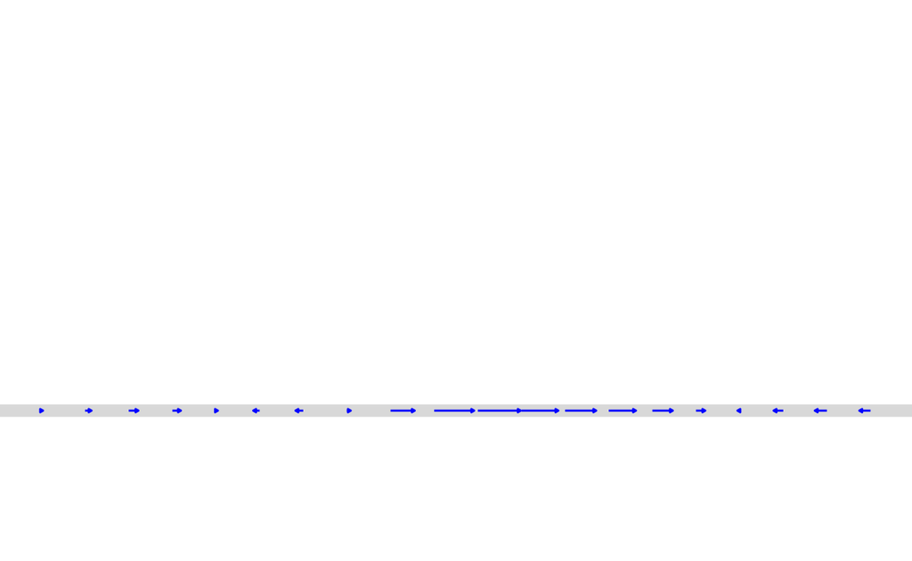

```r
Znotes::phase_line(dyn_function(x) ~ x, domain(x=-5:5), narrows=20, nix_dyn = TRUE)
```

This is a good place to emphasize that a dynamical function is always a function of the state variable(s), not a function of time. (It might have time in it, but that’s not our concern right now. The “solution” is a function of $t$, namely, $x(t)$.) It pays to emphasize over and over what are the inputs to dynamical functions and why they are entirely different from a “solution.”

## Fixed points

The fixed points are easily seen from the graphs of the dynamical functions; the zeros of the dynamical function. Make sure that students see that the length of the flow arrows are very small sufficiently near a fixed point and that an arrow drawn right at the function zero will have zero length.

Before going on to algebra (in the next section), conduct a few drills where students mark the fixed points for a displayed dynamical function.

Emphasize that there are (generically) two kinds of flows near a fixed point: (i) stable and (ii) unstable. Get the students to figure out what about the shape of the dynamical function near the fixed point determines the stability. Make sure that they see that the slope is $\partial_x f(x)$, the slope with respect to $x$. Re-emphasize that dynamical functions have inputs that are the state variables.

Conduct some drill to have students identify at a glance whether a fixed point is stable or unstable.

## Linearization and solution

You may want to review the idea of low-order polynomials and Taylor polynomials. At a fixed point $x_0$, the dynamical function is approximately $f(x) = f(x_0) + \partial_t f(x_0) [x - x_0]$. Since $f()$ has a fixed point at $x_0$, we know that $f(x_0) = 0$, so the dynamics are simply:

$f(x) = \partial_t f(x_0) [x - x_0]$

In the book, we go through the process of defining a new variable, $y = x-x+0$, showing that $\partial_t y = \partial_t x$ (notice: the derivative is with respect to time) and re-writing the differential equation as $\partial_t y = a y$.

Take any approach you like to demonstrating that the dynamics are $y(t) = A e^{a t}$, where $a$ is $\partial_t f(x_0)$. Key points:

1. The exponential form, which will show up again and again in later chapters.
2. The stability is set by $\partial_t f(x_0)$ as established in the previous section of these notes.

## The field/cow ecosystem

There’s a narrative description of this in the text and an interactive app [here](https://maa-statprep.shinyapps.io/Grazing_cows/) for drawing the functionsand varyig the number of cows. (But you might just as well have the students define in their R session the grass-growth curve and the grass-consumption curve, and generate the graph of the overall dynamics themselves.).